# Homework3

Mehmet Akif Taşcıoğlu

30 05 2021

## Introduction

In this study, the aim is to transform the non-stationary electricity consumption in Turkey data to a stationary one and use it to make predictions using the transformed data.Stationary data must have non-changing mean and variance over time. For this purpose, there are many tools to use. We can use power or log transformations to prevent increasing variance. We can detrend the data using decomposition or differencing to eliminate changing means. In order to check stationarity, we can use Ljung-Box and KPSS tests.

## Stationarity of the Data

```r
hourly_consumption <- read_excel("C:/Users/User/Desktop/ie360/hw3/GercekZamanliTuketim.xls")
hourly_consumption = data.table(hourly_consumption)
hourly_consumption$Date <- as.Date(hourly_consumption$Date, "%d.%m.%Y")
hourly_consumption[,Consumption:=gsub('\\.', '', Consumption)]
hourly_consumption[,Consumption:=gsub('\\,', '.', Consumption)]
hourly_consumption[,Consumption:=as.numeric(Consumption)]
head(hourly_consumption)
```

```
##          Date  Hour Consumption
## 1: 2016-01-01 00:00    26277.24
## 2: 2016-01-01 01:00    24991.82
## 3: 2016-01-01 02:00    23532.61
## 4: 2016-01-01 03:00    22464.78
## 5: 2016-01-01 04:00    22002.91
## 6: 2016-01-01 05:00    21957.08
```

```r
daily_consumption=hourly_consumption[,list(mean_consumption=mean(Consumption, na.rm = T)),by=list(Date)]
head(daily_consumption)
```

```
##          Date mean_consumption
## 1: 2016-01-01         27028.72
## 2: 2016-01-02         29275.35
## 3: 2016-01-03         28560.54
## 4: 2016-01-04         33121.03
## 5: 2016-01-05         33197.91
## 6: 2016-01-06         32634.51
```

```r
str(daily_consumption)
```

```
## Classes 'data.table' and 'data.frame':   1967 obs. of  2 variables:
##  $ Date            : Date, format: "2016-01-01" "2016-01-02" ...
##  $ mean_consumption: num  27029 29275 28561 33121 33198 ...
##  - attr(*, ".internal.selfref")=<externalptr>
```

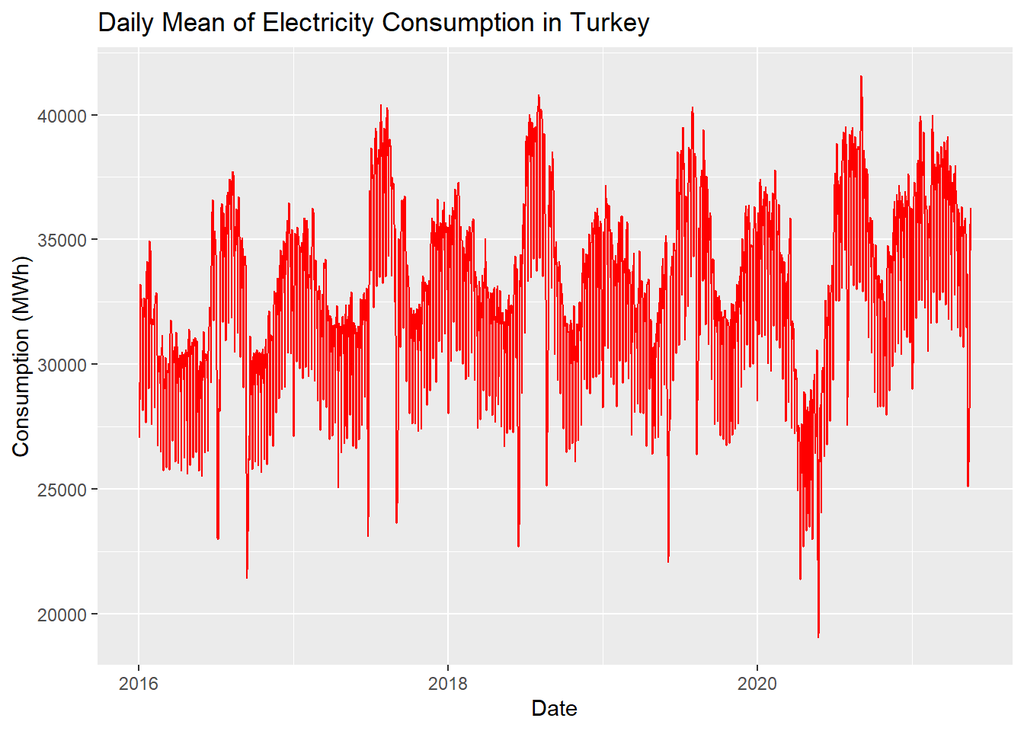

```r
ggplot(daily_consumption, aes(x=Date, y= mean_consumption)) + geom_line(color="red") + labs(title = "Daily Mean of Electricity Consumption in Turkey", x = "Date", y= "Consumption (MWh)")
```

Data have an obvious trend (not a linear one) over time since its mean is changing. Years are likely to have similar shapes due to yearly seasonalities which may be related to temperature and may be explained using month data. The variance also seems problematic probably due to some considerably lower consumptions on special days.As it is seen above, the mean goes up and down over time and variance is not constant at all, which are the two signs of non-stationarity.

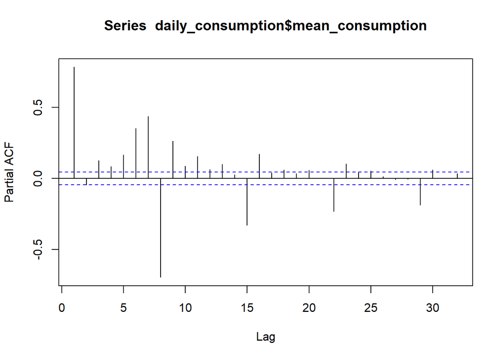

```r
pacf(daily_consumption$mean_consumption)
```

There is a strong positive partial autocorrelation at lag1 and lag7. Autocorrelation at lag7 can be explained as the day of the week actually affects the consumption, such as lower consumptions on Sundays.

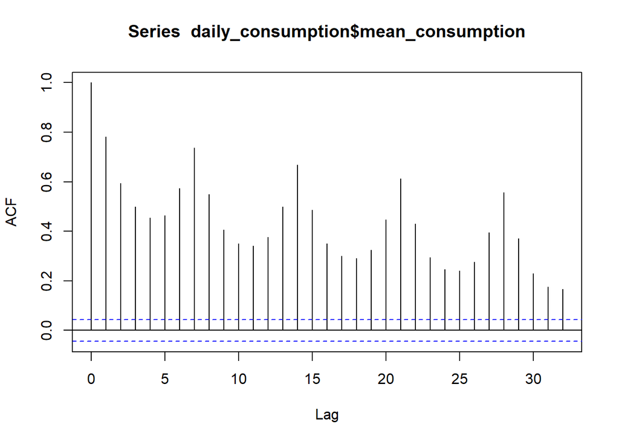

```r
acf(daily_consumption$mean_consumption)
```

The autocorrelation observed on data is too high to be stationary. Also, the pattern of the bars reflects the seasonality. As it is seen, the autocorrelation value is higher than its neighbors for lag 7, lag 14 etc. These values show that the seasonality of consumption data is weekly.For this data set, additive decomposition is prefered because the variance is not increasing over time.

## Decomposing at Daily Level

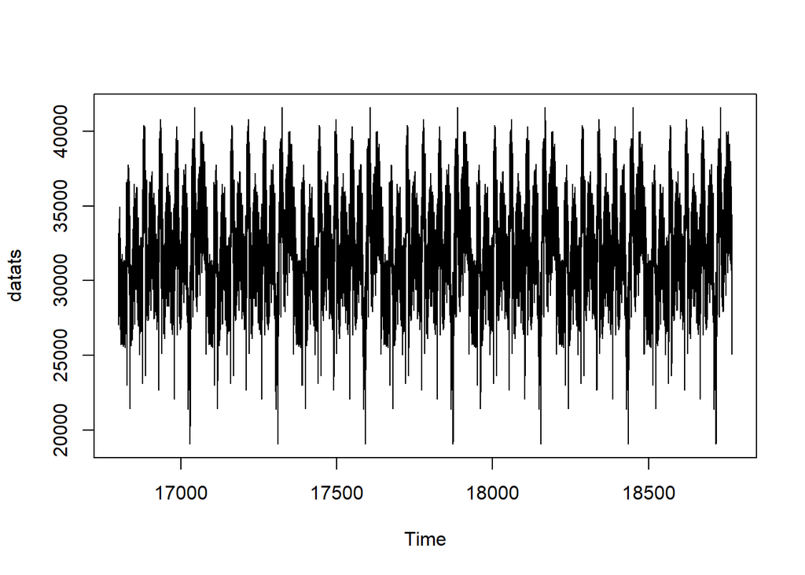

```r
datats <- ts(daily_consumption$mean_consumption, start = as.Date("2016-01-01"), end = as.Date("2021-05-20"), frequency = 7)
ts.plot(datats)
```

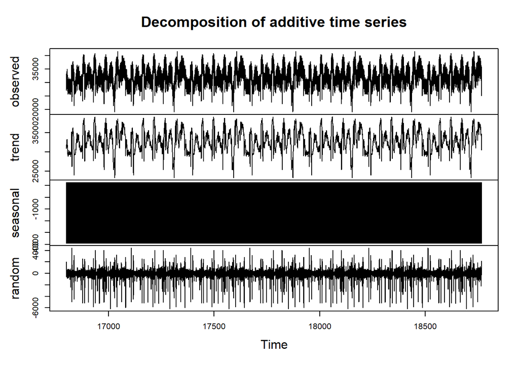

```r
ts_decomposed <- decompose(x = datats,type = "additive")
plot(ts_decomposed)
```

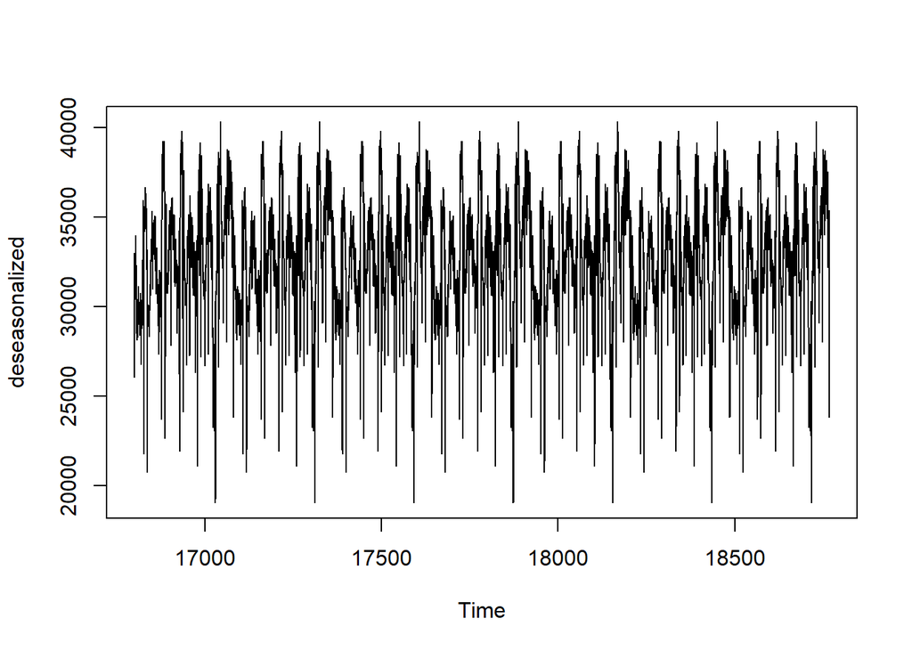

```r
deseasonalized<-datats-ts_decomposed$seasonal
ts.plot(deseasonalized)
```

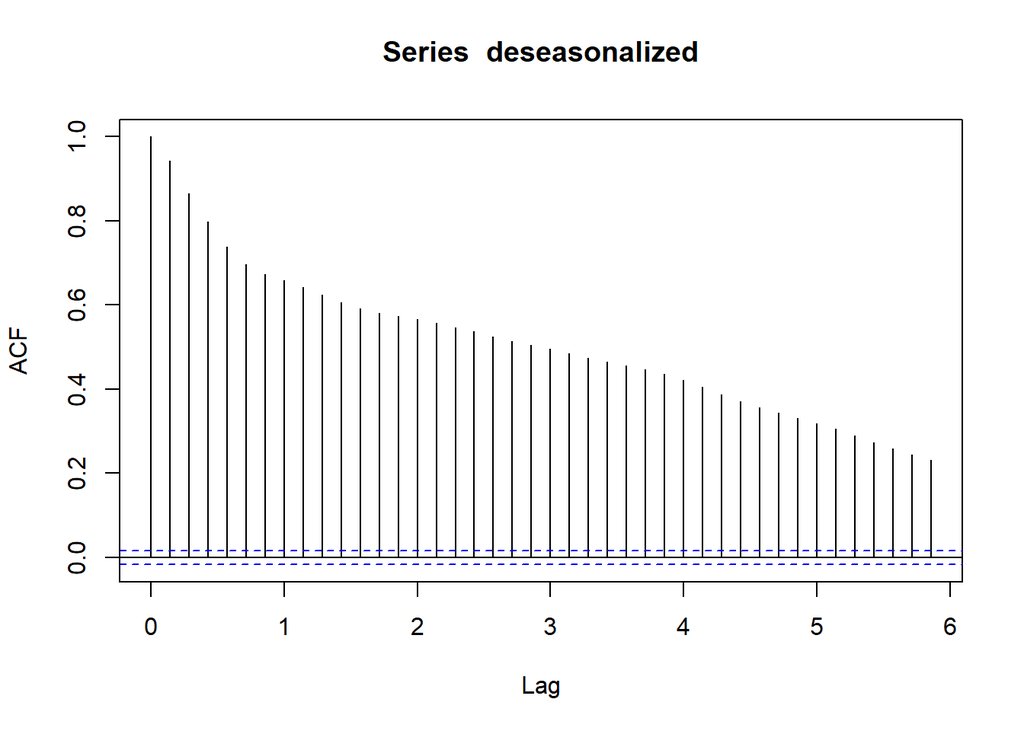

```r
acf(deseasonalized)
```

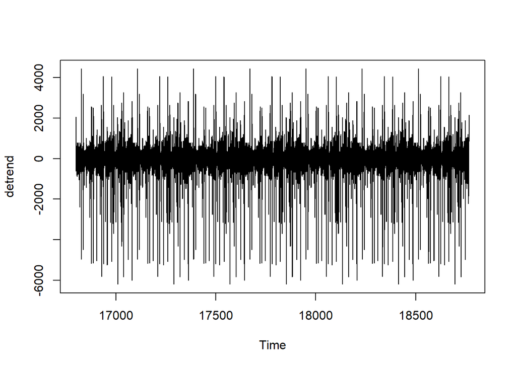

```r
detrend<-deseasonalized-ts_decomposed$trend
ts.plot(detrend)
```

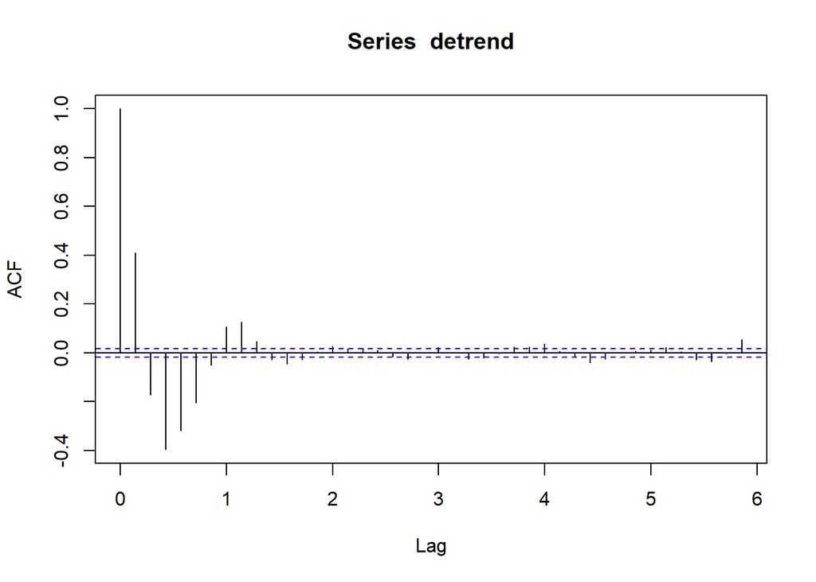

```r
acf(detrend, na.action = na.pass)
```

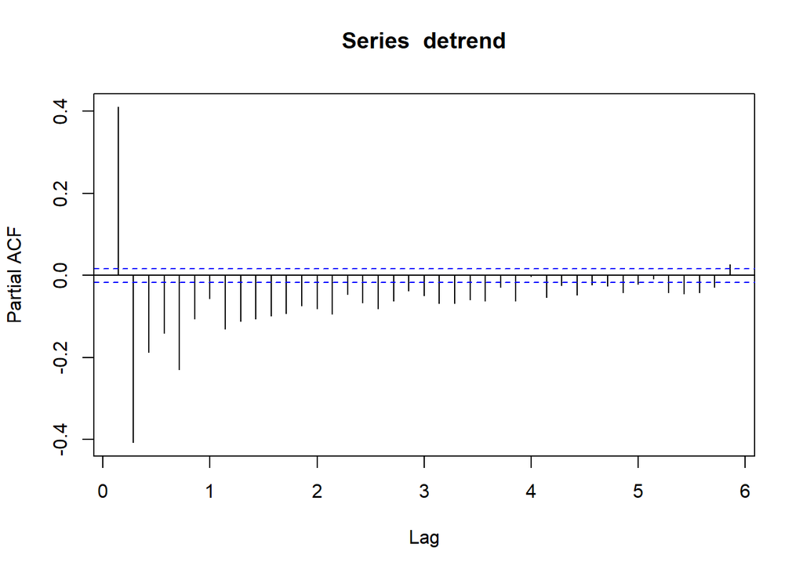

```r
pacf(detrend,na.action = na.pass)
```

## Seasonal Differencing

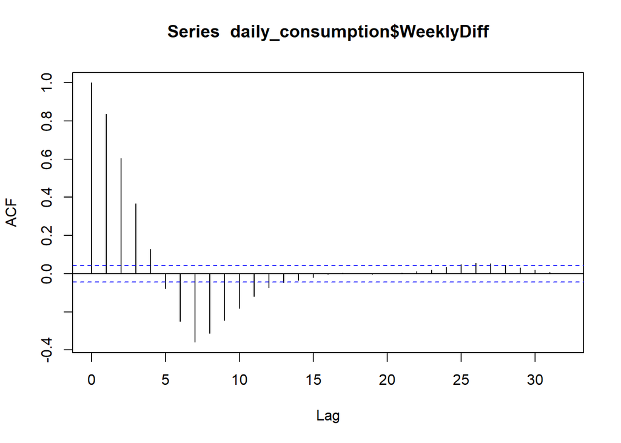

```r
daily_consumption[, WeeklyDiff := daily_consumption$mean_consumption-shift(daily_consumption$mean_consumption, 7)]
acf(daily_consumption$WeeklyDiff,na.action = na.pass)
```

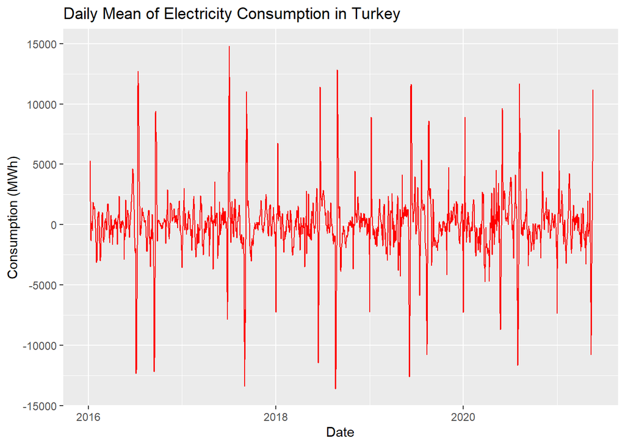

```r
ggplot(daily_consumption, aes(x=Date, y= WeeklyDiff)) + geom_line(color="red") + labs(title = "Daily Mean of Electricity Consumption in Turkey", x = "Date", y= "Consumption (MWh)")
```